# Distribuição de Probabilidade

### Distribuição Gama

A distribuição Gama é composta por 2 parâmetros (*alpha* e *beta*) e é um tipo de distribuição da qual fazem parte as distribuições: exponencial, chi-quadrado, erlang, etc.

Sua definição matemática é dada por:

[figure not shown]

Uma distribuição gama típica se parece com:

[figure not shown]

Agora vamos verificar sua implementação:

```python
from scipy.stats import gamma
data_gamma = gamma.rvs(a=5, size=10000, random_state=42)
```

```
[Text(0,0.5,'Frequency'), Text(0.5,0,'Gamma Distribution')]
```

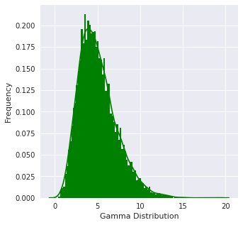

```python
ax = sns.distplot(data_gamma,
                  kde=True,
                  bins=100,
                  color='green',
                  hist_kws={"linewidth": 15,'alpha':1})
ax.set(xlabel='Gamma Distribution', ylabel='Frequency')
```

### Estatísticas da distribuição

Verificando as estatísticas da distribuição:

```python
#Média
print("Média: {0:8.4f}".format(data_normal.mean()))

#Mediana
print("Mediana: {0:8.4f}".format(np.median(data_normal)))

#Desvio padrão
print("Desvio padrão: {0:8.4f}".format(np.std(data_normal)))

#Variância
print("Variância: {0:8.4f}".format(np.var(data_normal)))
```

```
Média:  -0.0221
Mediana:  -0.0280
Desvio padrão:   0.9708
Variância:   0.9424
```

```python
#Média
print("Média: {0:8.4f}".format(data_gamma.mean()))

#Mediana
print("Mediana: {0:8.4f}".format(np.median(data_gamma)))

#Desvio padrão
print("Desvio padrão: {0:8.4f}".format(np.std(data_gamma)))

#Variância
print("Variância: {0:8.4f}".format(np.var(data_gamma)))
```

```
Média:   5.0354
Mediana:   4.7006
Desvio padrão:   2.2190
Variância:   4.9241
```

### Distribuição Exponencial

A distribuição exponencial descreve eventos que são afetados por uma taxa determinada pelo expoente x na fórmula:

[figure not shown]

Por causa do efeito exponencial, uma curva decrescente se parecerá com:

[figure not shown]

Para simularmos esta distribuição em Python, execute o código abaixo:

```python
from scipy.stats import expon
data_expon = expon.rvs(scale=1, loc=0, size=1000)
```

```
[Text(0,0.5,'Frequency'), Text(0.5,0,'Exponential Distribution')]
```

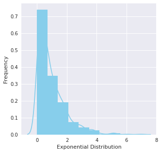

```python
#Agora vamos plotar os dados
ax = sns.distplot(
    data_expon,
    kde=True,
    bins=10,
    color='skyblue',
    hist_kws={'linewidth': 15, 'alpha': 1}
)

ax.set(xlabel='Exponential Distribution', ylabel='Frequency')
```

### Estatísticas da distribuição

Verificando as estatísticas da distribuição:

```python
#Média
print("Média: {0:8.4f}".format(data_normal.mean()))

#Mediana
print("Mediana: {0:8.4f}".format(np.median(data_normal)))

#Desvio padrão
print("Desvio padrão: {0:8.4f}".format(np.std(data_normal)))

#Variância
print("Variância: {0:8.4f}".format(np.var(data_normal)))
```

```
Média:  -0.0221
Mediana:  -0.0280
Desvio padrão:   0.9708
Variância:   0.9424
```

```python
#Média
print("Média: {0:8.4f}".format(data_expon.mean()))

#Mediana
print("Mediana: {0:8.4f}".format(np.median(data_expon)))

#Desvio padrão
print("Desvio padrão: {0:8.4f}".format(np.std(data_expon)))

#Variância
print("Variância: {0:8.4f}".format(np.var(data_expon)))
```

```
Média:   0.9496
Mediana:   0.6589
Desvio padrão:   0.9362
Variância:   0.8765
```

### Distribuição Binomial

Uma distribuição onde apenas dois outputs são possíveis (ex.: sucesso ou falha, perda ou ganho, vitória ou derrota, etc) e onde a probabilidade de cada opção é a mesma em todas as tentativas é chamada de Distribuição Binomial.

É importante ressaltar que, embora as probabilidades sejam iguais, os resultados não precisam ser proporcionalmente distribuídos, mesmo levando em conta a independência de cada rodada.

Os parâmetros de uma Distribuição Binomial são *n* que indica a quantidade de jogadas/rodadas e *p* que indica a probabilidade de sucesso de cada uma. A função de probabilidade é dada por:

[figure not shown]

Agora vamos gerar esta distribuição:

```python
from scipy.stats import binom
data_binom = binom.rvs(n=10,p=0.8,size=10000)
```

```
[Text(0,0.5,'Frequency'), Text(0.5,0,'Binomial Distribution')]
```

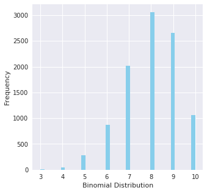

```python
ax = sns.distplot(data_binom,
                  kde=False,
                  color='skyblue',
                  hist_kws={"linewidth": 15,'alpha':1})
ax.set(xlabel='Binomial Distribution', ylabel='Frequency')
```

### Estatísticas da distribuição

Verificando as estatísticas da distribuição:

```python
#Média
print("Média: {0:8.4f}".format(data_normal.mean()))

#Mediana
print("Mediana: {0:8.4f}".format(np.median(data_normal)))

#Desvio padrão
print("Desvio padrão: {0:8.4f}".format(np.std(data_normal)))

#Variância
print("Variância: {0:8.4f}".format(np.var(data_normal)))
```

```
Média:  -0.0221
Mediana:  -0.0280
Desvio padrão:   0.9708
Variância:   0.9424
```

```python
#Média
print("Média: {0:8.4f}".format(data_binom.mean()))

#Mediana
print("Mediana: {0:8.4f}".format(np.median(data_binom)))

#Desvio padrão
print("Desvio padrão: {0:8.4f}".format(np.std(data_binom)))

#Variância
print("Variância: {0:8.4f}".format(np.var(data_binom)))
```

```
Média:   7.9931
Mediana:   8.0000
Desvio padrão:   1.2608
Variância:   1.5897
```